# case1_FINAL

Ian Hua, InHee Ho, Sonia Xu

September 18, 2017

# Introduction

The following data is from an international validation study (19 labs, 6 nations) of the rat uterotrophic bioassay. The purpose of the assay was to screen chemicals for estrogenic effects–agonist (EE) or antagonist (ZM). One clear challenge from the assay was the consistency among variables and protocols throughout all data in the study. The motivation of this study is to fit the best model against the data to identify potential differences between labs, and to assess the consistency and effectiveness of the two chemicals.

# Methodology

Our approach to answer our problem followed these 4 steps: 1. Data-cleaning 2. Exploratory Data Analysis 3. Fitting the data to a Linear Mixed-Effect Model 4. Interpreting the data, model, and results

# Dataset

```r
head(dat)
```

```
##      lab proto group dose1 dose2 body blot
## 1 Berlin     A     1     0     0 31.9 17.2
## 2 Berlin     A     1     0     0 31.1 20.5
## 3 Berlin     A     1     0     0 32.9 20.1
## 4 Berlin     A     1     0     0 31.6 16.5
## 5 Berlin     A     1     0     0 33.2 15.9
## 6 Berlin     A     1     0     0 30.6 26.1
```

## Exploratory Data Analysis

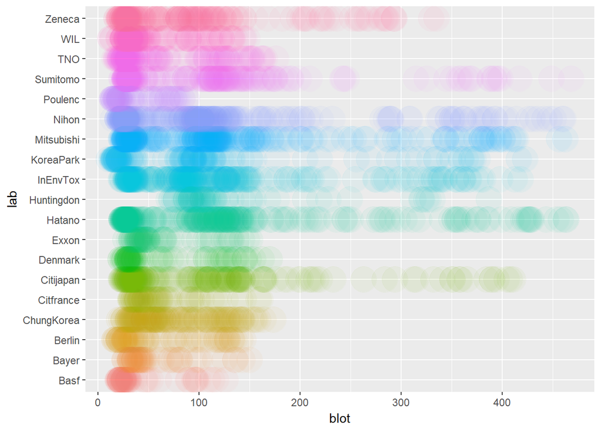

```r
#maybe implies that we should log(blot)? idk
ggplot(data = dat, aes(y = lab, x = blot, colour = lab)) + geom_point(alpha=0.05, size=10) + theme(legend.position="none")
```

Grouping the data by lab, let us take a closer look at the relationships between dose1, dose2, body, and blot. We can easily see the points at dose1 = 10.0 results in high leverage.

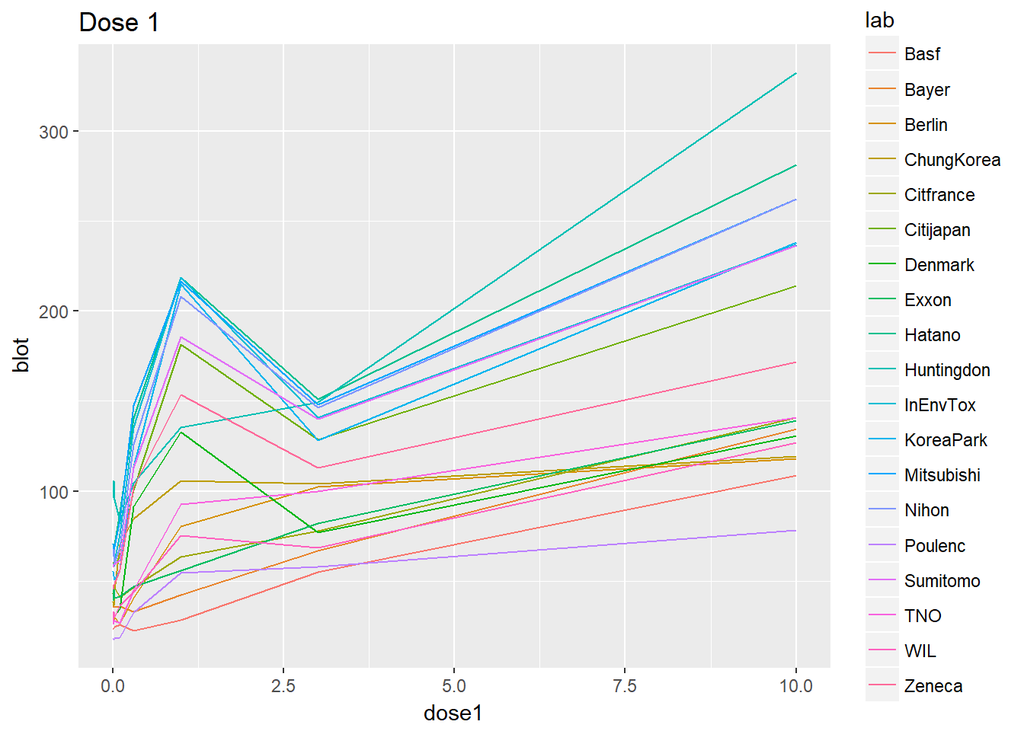

```r
mean_dat1 <- dat %>% group_by(lab, dose1) %>% summarise(blot = mean(blot))
ggplot(data = mean_dat1, aes(x = dose1, y = blot, color = lab)) + geom_line() + ggtitle("Dose 1")
```

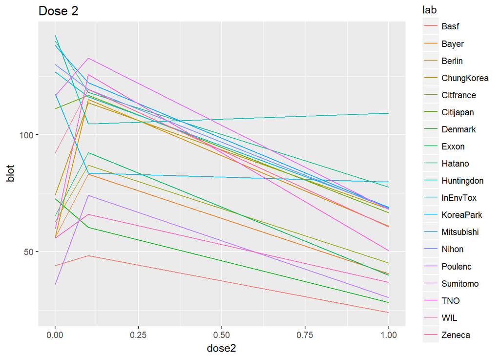

```r
mean_dat2 <- dat %>% group_by(lab, dose2) %>% summarise(blot = mean(blot))
ggplot(data = mean_dat2, aes(x = dose2, y = blot, color = lab)) + geom_line() + ggtitle("Dose 2")
```

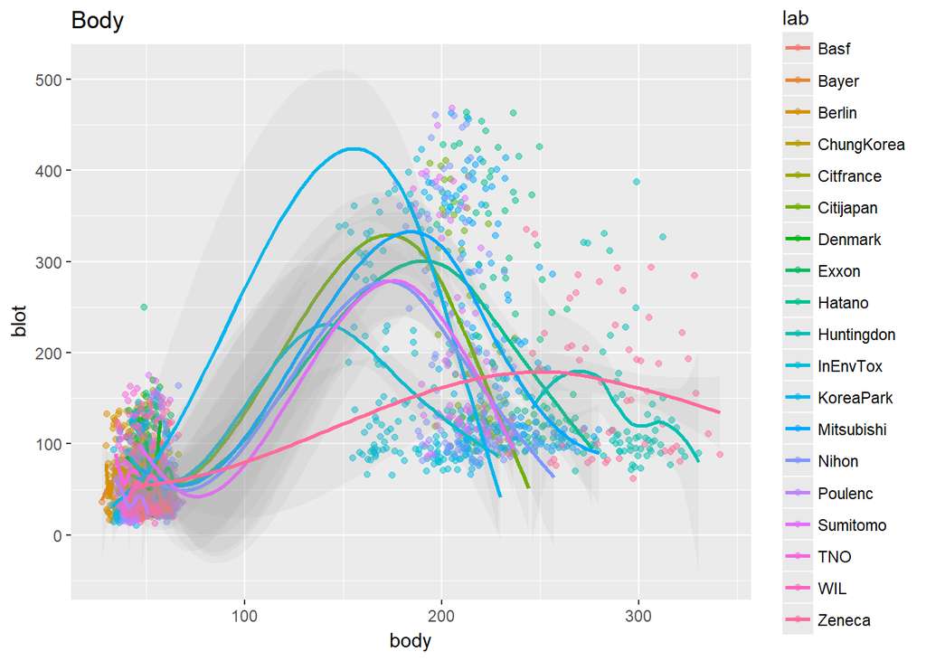

```r
mean_body <- dat %>% group_by(lab, body) %>% summarise(blot = mean(blot))
ggplot(data = mean_body, aes(x = body, y = blot, color = lab)) + geom_point(alpha = 0.5) + ggtitle("Body") + stat_smooth(alpha = 0.1)
```

It is critical to counter the leverage in our regression model - we apply a log on these explanatory variables to account for this leverage. After, we notice that the plots are not exactly linear and it is wiser to include a polynomial to better fit the model.

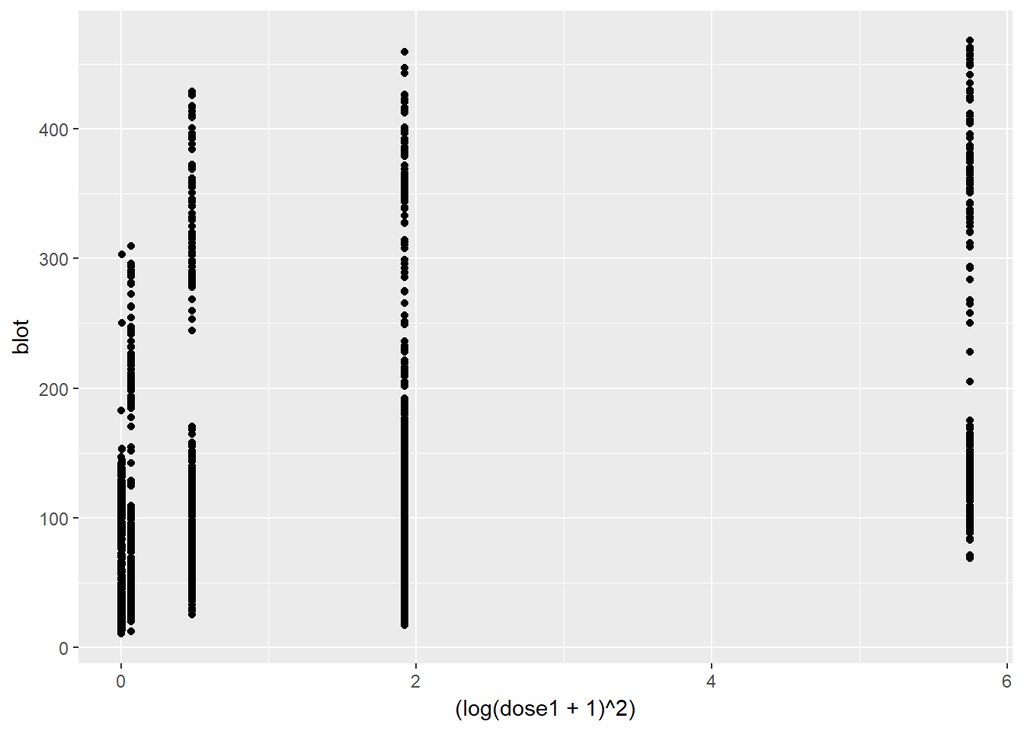

```r
ggplot(data = dat, aes(x=(log(dose1 +1)^2), y=blot)) + geom_point()
```

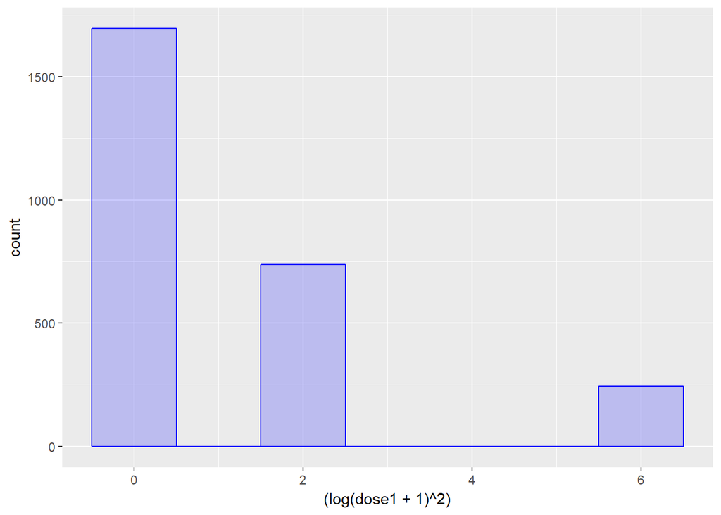

```r
ggplot(data = dat, aes((log(dose1 +1)^2))) + geom_histogram(fill = "blue", alpha = 0.2, binwidth = 1, col="blue")
```

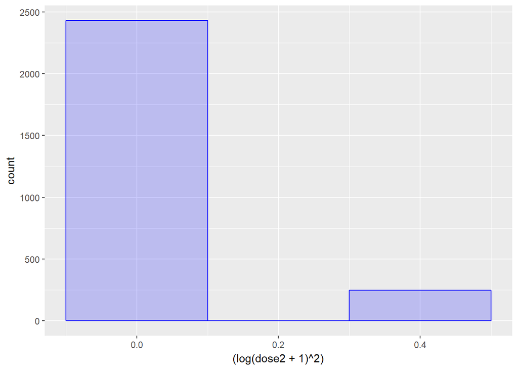

```r
ggplot(data = dat, aes((log(dose2 +1)^2))) + geom_histogram(fill = "blue", alpha = 0.2, binwidth = 0.2, col="blue")
```

Thus we use $log(dose1)^2$, $log(dose2)^2$, $log(body)^2$ in our model to fix this. Additionally, it is likely that the protocols at each lab differ due to a multitude of reasons, including environmental, procedural, governmental, etc. We treat this as a fixed effect and include this interaction influence in our final model.